# Replicate Specht et al. 2019 mass spectrometry-based single-cell proteomics analysis

Christophe Vanderaa[^1], Computational Biology, UCLouvain

Laurent Gatto, Computational Biology, UCLouvain

Abstract

Recent advances in sample preparation, processing and mass spectrometry (MS) have allowed the emergence of MS-based single-cell proteomics (SCP). This vignette presents a robust and standardized workflow to reproduce the data analysis of SCoPE2, one of the pioneering works in the field developed by the Slavov Lab. The implementation uses well-defined Bioconductor classes that provide powerful tools for single-cell RNA sequencing and for shotgun proteomics. We demonstrate that our pipeline can reproduce the SCoPE2 analysis using only a few lines of code.

# 1 Introduction

SCoPE2 (Specht et al. (2019)) is the first mass spectrometry (MS)-based single cell proteomics (SCP) protocol that has been used to profile thousands of proteins in thousands of cells. This is a technical milestone for SCP and it opens the door for fine-grain understanding of biological processes within and between cells at the protein level. The emergence of SCP data leads to the need of new computational developments that can deal with the specificities and challenges of this new type of data.

Although the authors provided all code and data required for fully reproducing their analysis, the code is difficult to read, implements many functions from scratch, and is based on generic table formats not suited for easy SCP data manipulation. This makes their workflow difficult to re-use for other analyses. Our goal is to bridge the gap between data acquisition and data interpretation by providing a new computational framework that is tailored for MS-SCP data. The SCoPE2 dataset is an ideal dataset to showcase its robustness and its ease of use.

### 1.0.1 Data framework and `scp`

Our first contribution is the development of a new data framework that combines two existing Bioconductor classes: the `SingleCellExperiment` that provides an interface to many cutting edge methods for single-cell analysis and `QFeatures` that facilitates manipulation and processing of MS-based quantitative data. See the [`scp` vignette](http://www.bioconductor.org/packages/release/bioc/vignettes/scp/inst/doc/scp.html) for more detailed information about the data structure. The `scp` package provides functionality for manipulating this MS-SCP data structure. `scp` is an extension to the `QFeatures` package. The emphasis is put on the standardization and the thorough documentation of the functions in order to (i) facilitate analysis for non-experts, (ii) provide an efficient environment for processing (large) MS-SCP data sets, (iii) be compatible for both multiplexed and label free quantification, the two main protocols for MS-SCP and (iv) facilitate the inclusion of external methods for promoting continuous improvement of the MS-SCP data analyses.

The required packages for running this workflow are listed below.

```r
## Core packages of this workflow
library(SingleCellExperiment)
library(QFeatures)
library(scpdata)
library(scp)
## Utility packages for data manipulation and visualization
library(tidyverse)
library(patchwork)
```

### 1.0.2 `scpdata` and the SCoPE2 dataset

We also implemented a data package called `scpdata`. It distributes published MS-SCP datasets, such as the SCoPE2 dataset. The datasets were downloaded from the data source provided in the publication and formatted to a `QFeatures` object so that it is compatible with our software. The underlying data storage is based on the `ExperimentHub` package that provides a cloud-based storage infrastructure.

The SCoPE2 dataset (Specht et al. (2019)) is provided at different levels of processing:

- The **raw data** files that were generated by the mass-spectrometer software.
- A **PSM data** table obtained from the MaxQuant software that performs spectrum identification and quantification. The provided table was further processed using DART-ID (Chen, Franks, and Slavov (2019)) to improve the identification rate.
- A **peptide data** table obtained from the SCoPE2 analysis script.
- A **protein data** table obtained as the final table from the SCoPE2 analysis script.

The workflow starts with the PSM table and will generate the peptide and the protein data. The authors provided the PSM dataset as a data table (`data.frame`). The files can be downloaded from SCoPE2 repository of the Slavov Lab [website](http://scope2.slavovlab.net/). The formatted SCoPE2 dataset can be retrieved from the `scpdata` package with the `specht2019v3()` function. Note that `v3` stands for the third version release of the data in October 2020.

```r
scp <- specht2019v3()
```

```
## snapshotDate(): 2021-02-11
```

```
## see ?scpdata and browseVignettes('scpdata') for documentation
```

```
## loading from cache
```

The data contain 179 different `SingleCellExperiment` objects that we refer to as **assays**. Each assay contains expression data along with feature metadata. Below, we show the overview of the `scp` dataset.

```r
scp
```

```
## An instance of class QFeatures containing 179 assays:
##  [1] 190222S_LCA9_X_FP94AA: SingleCellExperiment with 2777 rows and 11 columns
##  [2] 190222S_LCA9_X_FP94AB: SingleCellExperiment with 4348 rows and 11 columns
##  [3] 190222S_LCA9_X_FP94AC: SingleCellExperiment with 4917 rows and 11 columns
##  ...
##  [177] 191110S_LCB7_X_APNOV16plex2_Set_9: SingleCellExperiment with 4934 rows and 16 columns
##  [178] peptides: SingleCellExperiment with 9354 rows and 1490 columns
##  [179] proteins: SingleCellExperiment with 3042 rows and 1490 columns
```

177 out of the 179 assays are PSM data, each assay corresponding to a separate MS run. 63 contain 11 columns and 114 contain 16 columns. This is because the SCoPE2 protocol first included TMT-11 multiplexing, but soon the TMT-16 multiplexing was released and the authors decided to switch to the latter to increase the throughput of the technique. Notice that the assays were also acquired in 4 chromatographic batches. Here is an overview of the distribution of the assays across the TMT and chromatographic batches.

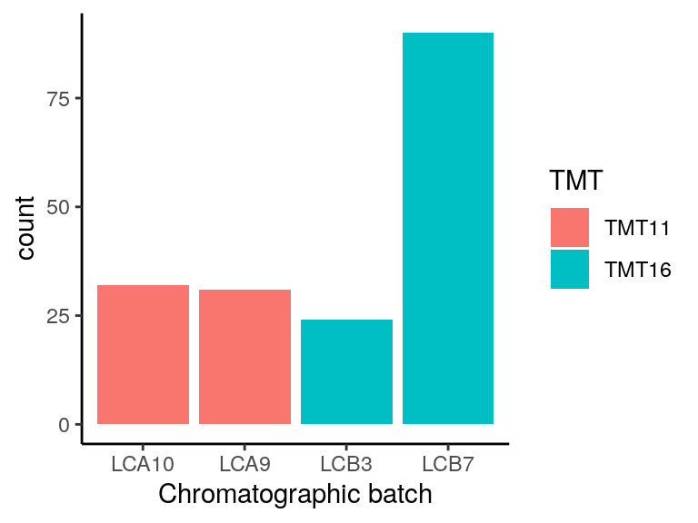

```r
colData(scp) %>%
    data.frame %>%
    select(c(Set, lcbatch)) %>%
    unique %>%
    mutate(TMT = ifelse(grepl("16plex", Set), "TMT16", "TMT11")) %>%
    ggplot() +
    aes(x = lcbatch,
        fill = TMT) +
    geom_histogram(stat = "count") +
    xlab("Chromatographic batch") +
    theme_classic()
```

The dataset also contains a `peptides` assay and a `proteins` assay that hold peptide and protein level information, respectively. The objective of this vignette is to produce the `peptides` and `proteins` assays from the 177 PSM assays following the same procedure as the SCoPE2 script but using standardized functionalities.

We extract the `peptides` and `proteins` assays and keep them for later benchmarking. Using double brackets `[[...]]` extracts the desired assay as a `SingleCellExperiment` object. On the other hand, using simple brackets `[row, col, assay]` subsets the desired elements/assays but preserves the `QFeatures` data structure.

```r
peptides_SCoPE2 <- scp[["peptides"]]
proteins_SCoPE2 <- scp[["proteins"]]
scp <- scp[, , -(178:179)]
```

```
## harmonizing input:
##   removing 2980 sampleMap rows not in names(experiments)
```

To avoid confusions during later benchmarking of the replication, we name the peptide and protein data sets generated by the SCoPE2 script `peptides_SCoPE2` and `proteins_SCoPE2`, respectively.

## 1.1 The SCoPE2 workflow

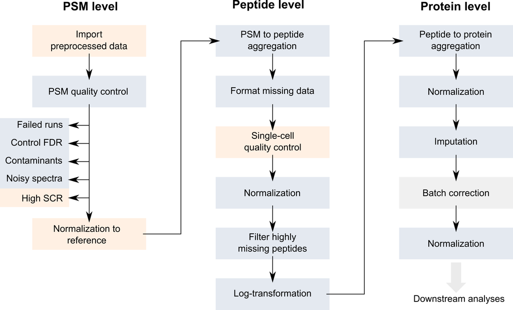

(#fig:SCoPE2_workflow)Overview of the SCoPE2 workflow.

The SCoPE2 code provided along with the article can be retrieved from [this GitHub repository](https://github.com/SlavovLab/SCoPE2/blob/master/code/SCoPE2_analysis.R). Note that we here used the part of the script that performs the stringent feature selection (see the original paper for more details).

The objective of this vignette is to replicate the SCoPE2 script while providing standardized, easy-to-read, and well documented code. We will demonstrate the success of the replication with a little benchmarking of our results against the data provided by the authors. Finally, we will perform some further data exploration to highlight the remaining challenges that still require to be tackled in MS-based SCP.

# 2 Filter the PSM data

The SCoPE2 analysis starts with filtering low-confidence PSMs. Each PSM assay contains feature meta-information that are stored in the assay `rowData`. The `QFeatures` package allows to quickly filter the rows of an assay by using these information. The available variables in the `rowData` are listed below for each assay.

```r
rowDataNames(scp)
```

```
## CharacterList of length 177
## [["190222S_LCA9_X_FP94AA"]] uid Sequence Length ... digest modseq peptide
## [["190222S_LCA9_X_FP94AB"]] uid Sequence Length ... digest modseq peptide
## [["190222S_LCA9_X_FP94AC"]] uid Sequence Length ... digest modseq peptide
## [["190222S_LCA9_X_FP94AD"]] uid Sequence Length ... digest modseq peptide
## [["190222S_LCA9_X_FP94AE"]] uid Sequence Length ... digest modseq peptide
## [["190222S_LCA9_X_FP94AF"]] uid Sequence Length ... digest modseq peptide
## [["190222S_LCA9_X_FP94AG"]] uid Sequence Length ... digest modseq peptide
## [["190222S_LCA9_X_FP94AH"]] uid Sequence Length ... digest modseq peptide
## [["190222S_LCA9_X_FP94AI"]] uid Sequence Length ... digest modseq peptide
## [["190222S_LCA9_X_FP94AJ"]] uid Sequence Length ... digest modseq peptide
## ...
## <167 more elements>
```

## 2.1 Filter out failed runs based on PSM content

First, only the assays that have sufficient PSMs are kept. The authors keep an assay if it has over 500 PSMs. Before filtering, let’s first look at the distribution of the number of PSMs per assay. Note that we can easily extract the number of rows (here PSMs) and the number of columns (TMT channels) of each assay using the `dims` function implemented in `QFeatures`.

```r
nPSMs <- dims(scp)[1, ]
```

Let’s have a look at the number of features that were identified in the different runs.

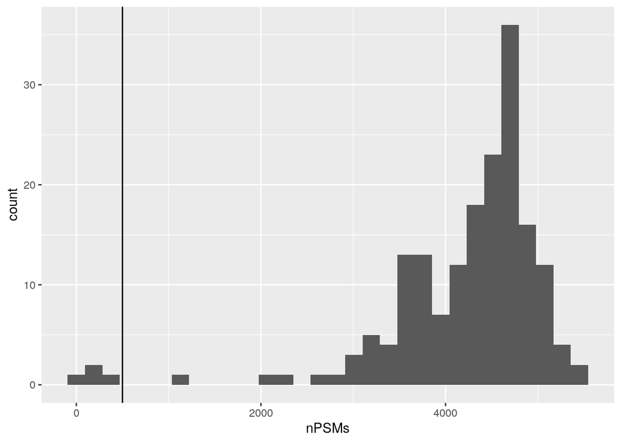

```r
ggplot(data.frame(nPSMs)) +
    aes(x = nPSMs) +
    geom_histogram() +
    geom_vline(xintercept = 500)
```

4 assays have very few number of PSMs, probably because those runs failed. They are hence below the threshold of 500 and are removed from the analysis. To perform this, we take advantage of the subsetting method of a `QFeatures` object. It can be seen as a three-order array: $features \times samples \times assay$. Hence, `QFeatures` supports three-order subsetting `x[rows, columns, assays]`.

```r
scp <- scp[, , nPSMs > 500]
```

```
## Warning: 'experiments' dropped; see 'metadata'
```

```
## harmonizing input:
##   removing 59 sampleMap rows not in names(experiments)
##   removing 59 colData rownames not in sampleMap 'primary'
```

You may notice that a warning is thrown when performing the subsetting step. This is because, as we expected, a few assays were dropped. We can find them back in the `metadata` slot:

```r
metadata(scp)
```

```
## $drops.experiments
## [1] "peptides"                          "proteins"
## [3] "190222S_LCA9_X_FP94BD"             "191026S_LCB7_X_AP16plex_Set_15"
## [5] "191108S_LCB7_X_APNOV16plex_Set_24" "191108S_LCB7_X_APNOV16plex_Set_29"
```

## 2.2 Filter out PSMs with high false discovery rate

Next, SCoPE2 filters PSMs based on the false discovery rate (FDR) for identification. As mentioned in the introduction, the PSM data were already processed with DART-ID (Chen, Franks, and Slavov (2019)), a python software that updates the confidence in peptide identification using an Bayesian inference approach. DART-ID outputs for every PSM the updated posterior error probability (PEP). Filtering on the PEP is too conservative and it is rather advised to filter based on FDR (Käll et al. (2008)). To control for the FDR, we need to compute q-values, that correspond to the minimal FDR threshold that would still select the associated feature.

We can easily compute q-values from the PEPs computed by MaxQuant or updated by DART-ID using the `pep2qvalue` function. In the SCoPE workflow, the features are selected based on the FDR at PSM level and at protein level. The PEP information (`dart_PEP`) as well as the protein information (`protein`) are retrieved from the `rowData` of each assay. The function will store the computed q-values in the `rowData` and we give the name of `qvalue_psm` and `qvalue_protein` for the PSM and proteins q-values, respectively.

```r
scp <- pep2qvalue(scp,
                  i = names(scp),
                  PEP = "dart_PEP",
                  rowDataName = "qvalue_psm")
scp <- pep2qvalue(scp,
                  i = names(scp),
                  groupBy = "protein",
                  PEP = "dart_PEP",
                  rowDataName = "qvalue_protein")
```

We can extract the q-values from the `rowData` of several assays using the `rowDataToDF` function. It takes the `rowData` of interest and returns a single `DataFrame` table with variables of interest. We plot the q-values along with the DART-ID PEPs using `ggplot2` facets.

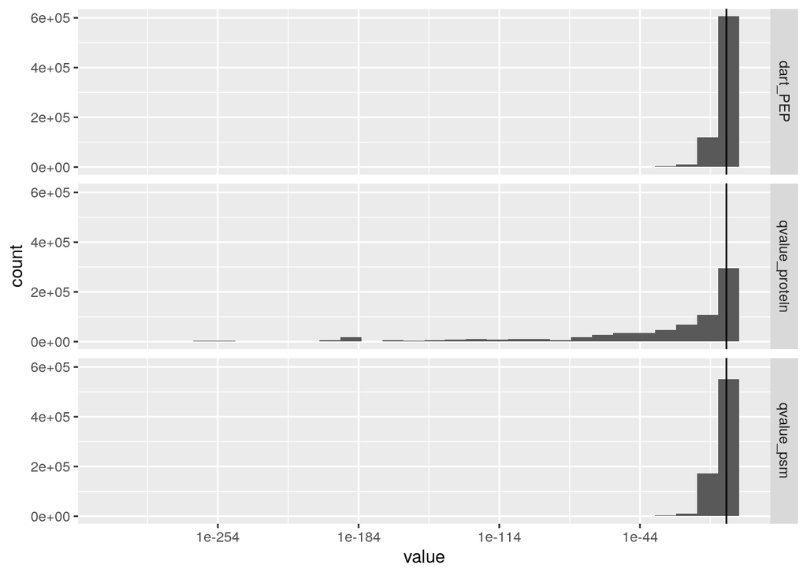

```r
rowDataToDF(scp,
            i = names(scp),
            vars = c("dart_PEP", "qvalue_psm", "qvalue_protein")) %>%
    data.frame %>%
    pivot_longer(cols = c("dart_PEP", "qvalue_psm", "qvalue_protein"),
                 names_to = "measure") %>%
    ggplot(aes(x = value)) +
    geom_histogram() +
    geom_vline(xintercept = 0.1) +
    scale_x_log10() +
    facet_grid(rows = vars(measure))
```

We filter the PSMs to control for a 1% PSM and protein FDR. We can easily perform this on our `QFeatures` object by using the `filterFeatures` function. The q-values are directly accessed from the `rowData` of each assay.

```r
scp <- filterFeatures(scp,
                      ~ qvalue_psm < 0.01 & qvalue_protein < 0.01)
```

## 2.3 Filter out contaminants

We will now remove PSMs that were matched to contaminant proteins (the protein name starts with `CON`) or to the decoy database (the protein name starts with `REV`). Again, `filterFeatures` can directly access the protein names from the `rowData`.

```r
scp <- filterFeatures(scp,
                      ~ !grepl("REV|CON", protein))
```

## 2.4 Filter out noisy spectra

A PIF (parental ion fraction) smaller than 80 % indicates the associated spectra is contaminated by co-isolated peptides and therefore the quantification becomes unreliable. The PIF was computed by MaxQuant and is readily available for filtering.

```r
scp <- filterFeatures(scp,
                      ~ !is.na(PIF) & PIF > 0.8)
```

## 2.5 Filter out PSMs with high sample to carrier ratio

The PSMs are next filtered based on the sample to carrier ratio (SCR), that is the reporter ion intensity of a single-cell sample divided by the reporter ion intensity of the carrier (200 cells) acquired during the same run as the sample. It is expected that the carrier intensities are much higher than the single-cell intensities. We implemented the `computeSCR` function that computes the SCR for each PSM averaged over all samples of interest in a given assay. A PSM is removed when the mean SCR exceeds 10 %. To perform this, we need to tell the function which columns are the samples of interest and which is the carrier. The `colData` of the `QFeatures` object is used to define this.

```r
table(scp$SampleType)
```

```
##
##      Blank    Carrier Macrophage   Monocyte  Reference     Unused
##        168        173       1198        462        173        284
```

In this dataset, `SampleType` gives the type of sample that is present in each TMT channel. The SCoPE2 protocol includes 5 types of samples: * The carrier channels (`Carrier`) contain 200 cell equivalents and are meant to boost the peptide identification rate. * The normalization channels (`Reference`) contain 5 cell equivalents and are used to partially correct for between-run variation. * The unused channels (`Unused`) are channels that are left empty due to isotopic cross-contamination by the carrier channel. * The blank channels (`Blank`) contain samples that do not contain any cell but are processed as single-cell samples. * The single-cell sample channels contain the single-cell samples of interest (`Macrophage` or `Monocyte`).

```r
scp <- computeSCR(scp,
                  i = names(scp),
                  colDataCol = "SampleType",
                  carrierPattern = "Carrier",
                  samplePattern = 4:16)
```

Before applying the filter, we plot the distribution of the mean SCR.

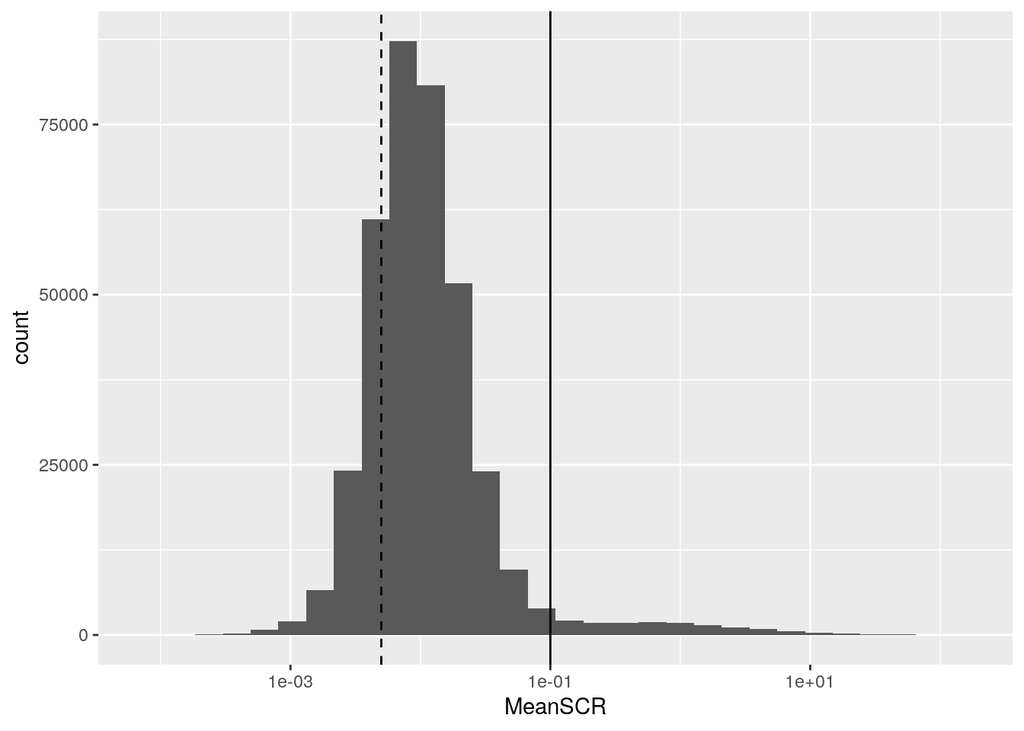

```r
rowDataToDF(scp,
            i = names(scp),
            vars = "MeanSCR") %>%
    data.frame %>%
    ggplot(aes(x = MeanSCR)) +
    geom_histogram() +
    geom_vline(xintercept = c(1/200, 0.1),
               lty = 2:1) +
    scale_x_log10()
```

A great majority of the PSMs have a mean SCR that is lower than 10%, as expected. Interestingly, the mode of the distribution is located at ~1%. This is expected since every sample channel contains a single-cell and the carrier contains 200 cells leading to an expected ratio of 0.5% (dashed line). We remove the PSMs for which the mean SCR exceeds the 10% threshold.

```r
scp <- filterFeatures(scp,
                      ~ !is.na(MeanSCR) &
                          !is.infinite(MeanSCR) &
                          MeanSCR < 0.1)
```

# 3 Normalize to reference

In order to partially correct for between-run variation, SCoPE2 computes relative reporter ion intensities. This means that intensities measured for single-cells are divided by the reference channel containing 5-cell equivalents. We use the `divideByReference` function that divides channels of interest by the reference channel. Similarly to `computeSCR`, we can point to the samples and the reference columns in each assay using the annotation contained in the `colData`. We will here divide all columns (using the regular expression wildcard `.`) by the reference channel (`Reference`). Notice that when taking all samples we also include the reference channel. Hence, from now on, the reference channels will contain only `1`s.

```r
scp <- divideByReference(scp,
                         i = names(scp),
                         colDataCol = "SampleType",
                         samplePattern = ".",
                         refPattern = "Reference")
```

# 4 Aggregate PSM data to peptide data

Now that the PSM assays are processed, we can aggregate them to peptides. This is performed using the `aggregateFeaturesOverAssays` function. This is a wrapper function in `scp` that sequentially calls the `aggregateFeatures` from the `QFeatures` package over the different assays. For each assay, the function aggregates several PSMs into a unique peptide given an aggregating variable in the `rowData` (peptide sequence) and a user-supplied aggregating function (the median for instance). Regarding the aggregating function, the SCoPE2 analysis removes duplicated peptide sequences per run by taking the first non-missing value. While better alternatives are documented in `QFeatures::aggregateFeatures`, we still use this approach for the sake of replication and for illustrating that custom functions can be applied.

```r
remove.duplicates <- function(x)
    apply(x, 2, function(xx) xx[which(!is.na(xx))[1]] )
```

The aggregated peptide assays must be given a name. We here used the original names with `peptides_` at the start.

```r
peptideAssays <- paste0("peptides_", names(scp))
```

We now have all the required information to aggregate the PSMs in the different batches to peptides.

```r
scp <- aggregateFeaturesOverAssays(scp,
                                   i = names(scp),
                                   fcol = "peptide",
                                   name = peptideAssays,
                                   fun = remove.duplicates)
```

Under the hood, the `QFeatures` architecture preserves the relationship between the aggregated assays. See `?AssayLinks` for more information on relationships between assays. Notice that `aggregateFeaturesOverAssays` created as many new assays as the number of supplied assays.

```r
scp
```

```
## An instance of class QFeatures containing 346 assays:
##  [1] 190222S_LCA9_X_FP94AA: SingleCellExperiment with 1098 rows and 11 columns
##  [2] 190222S_LCA9_X_FP94AB: SingleCellExperiment with 2420 rows and 11 columns
##  [3] 190222S_LCA9_X_FP94AC: SingleCellExperiment with 2775 rows and 11 columns
##  ...
##  [344] peptides_191110S_LCB7_X_APNOV16plex2_Set_7: SingleCellExperiment with 2379 rows and 16 columns
##  [345] peptides_191110S_LCB7_X_APNOV16plex2_Set_8: SingleCellExperiment with 2480 rows and 16 columns
##  [346] peptides_191110S_LCB7_X_APNOV16plex2_Set_9: SingleCellExperiment with 2308 rows and 16 columns
```

# 5 Join the SCoPE2 sets in one assay

Up to now, we kept the data belonging to each MS run in separate assays. We now combine all batches into a single assay. This can easily be done using the `joinAssays` function from the `QFeatures` package.

We however need to account for an issue. The `joinAssays` will only keep the metadata variables that have the same value between matching rows. However, some peptide sequences map to one protein in one run and to another protein in another run. Hence, the protein sequence is not constant for all peptides and is removed during joining. It is important we keep the protein sequence in the `rowData` since we will later need it to aggregate peptides to proteins. To avoid this issue, we replace the problematic peptides to protein mappings through majority vote.

```r
scp %>%
    rowDataToDF(i = names(scp)[1:173],
                vars = c("peptide", "protein")) %>%
    data.frame %>%
    group_by(peptide) %>%
    ## The majority vote happens here
    mutate(protein = names(sort(table(protein),
                                decreasing = TRUE))[1]) %>%
    select(peptide, protein) %>%
    filter(!duplicated(peptide, protein)) ->
    ppMap
for (i in peptideAssays) {
    pep <- rowData(scp[[i]])$peptide
    ## TODO: using `@` is a bad idea!! I should find a way to optimize
    ## rowData(scp[[i]])$protein <- ... without using `@` (maybe
    ## contact M. Ramos)
    rowData(scp@ExperimentList@listData[[i]])$protein <-
        ppMap$protein[match(pep, ppMap$peptide)]
}
```

Now that the peptides are correctly matched to proteins, we can join the assays.

```r
scp <- joinAssays(scp,
                  i = peptideAssays,
                  name = "peptides")
```

```
## harmonizing input:
##   removing 2458 sampleMap rows not in names(experiments)
```

`joinAssays` has created a new assay called `peptides` that combines the previously aggregated peptide assays.

```r
scp
```

```
## An instance of class QFeatures containing 347 assays:
##  [1] 190222S_LCA9_X_FP94AA: SingleCellExperiment with 1098 rows and 11 columns
##  [2] 190222S_LCA9_X_FP94AB: SingleCellExperiment with 2420 rows and 11 columns
##  [3] 190222S_LCA9_X_FP94AC: SingleCellExperiment with 2775 rows and 11 columns
##  ...
##  [345] peptides_191110S_LCB7_X_APNOV16plex2_Set_8: SingleCellExperiment with 2480 rows and 16 columns
##  [346] peptides_191110S_LCB7_X_APNOV16plex2_Set_9: SingleCellExperiment with 2308 rows and 16 columns
##  [347] peptides: SingleCellExperiment with 15675 rows and 2458 columns
```

# 6 Format the missing data

SCoPE2 performs a cleaning step were zero and infinite values are replaced by NAs. The `infIsNA` and the `zeroIsNA` functions are provided by the `QFeatures` package.

```r
scp <- infIsNA(scp, i = "peptides")
scp <- zeroIsNA(scp, i = "peptides")
```

# 7 Filter single-cells based on median CV

```r
scp <- computeMedianCV_SCoPE2(scp,
                              i = "peptides",
                              proteinCol = "protein",
                              peptideCol = "peptide",
                              batchCol = "Set")
# scp <- medianCVperCell(scp,
#                        i = peptideAssays,
#                        groupBy = "protein",
#                        nobs = 5,
#                        na.rm = TRUE,
#                        colDataName = "MedianCV",
#                        norm = c("div.median", "mean"))
```

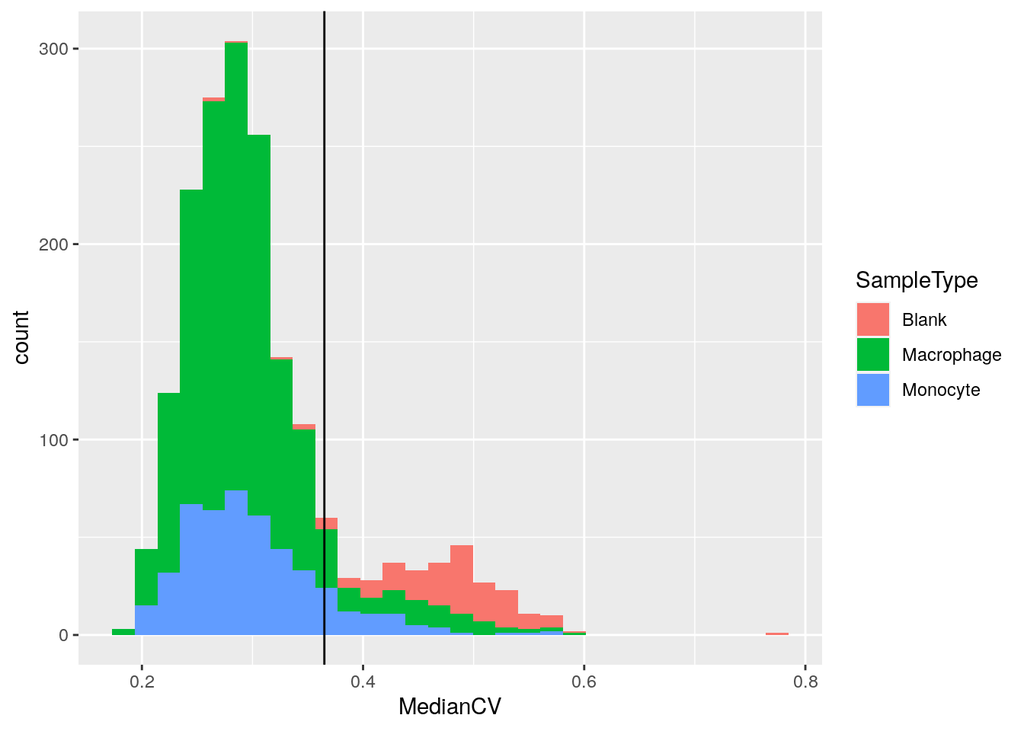

```r
getWithColData(scp, i = "peptides") %>%
    colData %>%
    data.frame %>%
    filter(SampleType %in% c("Macrophage",  "Monocyte", "Blank")) %>%
    ggplot(aes(x = MedianCV,
               fill = SampleType)) +
    geom_histogram() +
    geom_vline(xintercept = 0.365)
```

We keep the cells that pass the median CV threshold. Furthermore, we keep macrophages and monocytes as those represent the samples of interest. Now the quality control and filtering is performed, we can remove the other channels.

We have already demonstrated how to remove assays from the dataset, but we can apply a similar subsetting for the samples present in the `colData`. Recall that the second entry in the `[` subsetting method is for samples.

```r
scp <- scp[, scp$MedianCV < 0.365 &
               scp$SampleType %in% c("Macrophage", "Monocyte"), ]
```

```
## harmonizing input:
##   removing 2 sampleMap rows with 'colname' not in colnames of experiments
```

**(**todo?**)** this is slow and requires optimization.

```r
scp
```

```
## An instance of class QFeatures containing 347 assays:
##  [1] 190222S_LCA9_X_FP94AA: SingleCellExperiment with 1098 rows and 4 columns
##  [2] 190222S_LCA9_X_FP94AB: SingleCellExperiment with 2420 rows and 5 columns
##  [3] 190222S_LCA9_X_FP94AC: SingleCellExperiment with 2775 rows and 6 columns
##  ...
##  [345] peptides_191110S_LCB7_X_APNOV16plex2_Set_8: SingleCellExperiment with 2480 rows and 11 columns
##  [346] peptides_191110S_LCB7_X_APNOV16plex2_Set_9: SingleCellExperiment with 2308 rows and 11 columns
##  [347] peptides: SingleCellExperiment with 15675 rows and 1499 columns
```

# 8 Process the peptide data

In the SCoPE2 analysis, the peptide data is first transformed before it is aggregated to proteins. The transformation steps are: normalization, filter peptides based on missing data and log-transformation.

## 8.1 Normalization

The columns (samples) of the peptide data are first normalized by dividing the relative intensities by the median relative intensities. Then, the rows (peptide) are normalized by dividing the relative intensities by the mean relative intensities. The normalized data is stored in a separate assay.

```r
scp %>%
    ## Scale columns with median
    sweep(i = "peptides",
          MARGIN = 2,
          FUN = "/",
          STATS = colMedians(assay(.[["peptides"]]),
                             na.rm = TRUE),
          name = "peptides_norm1") %>%
    ## Scale rows with mean
    sweep(i = "peptides_norm1",
          MARGIN = 1,
          FUN = "/",
          STATS = rowMeans(assay(.[["peptides_norm1"]]),
                           na.rm = TRUE),
          name = "peptides_norm2") ->
    scp
```

## 8.2 Remove peptides with high missing rate

Peptides that contain many missing values are not informative. Therefore, we remove those with more than 99 % missing data. This is done using the `filterNA` function from `QFeatures`.

```r
scp <- filterNA(scp,
                i = "peptides_norm2",
                pNA = 0.99)
```

## 8.3 Log-transformation

The last processing step of the peptide data before aggregating to proteins is to log-transform the data. SCoPE2 uses a base 2 log-transformation.

```r
scp <- logTransform(scp,
                    base = 2,
                    i = "peptides_norm2",
                    name = "peptides_log")
```

## 8.4 The SCoPE2 peptide data

Before exporting the data as `Peptides-raw.csv`, the authors performed an additional normalization step. This step is however not considered in the remainder of the workflow.

```r
scp %>%
    ## Center columns with median
    sweep(i = "peptides_log",
          MARGIN = 2,
          FUN = "-",
          STATS = colMedians(assay(.[["peptides_log"]]),
                             na.rm = TRUE),
          name = "peptides_log_norm1") %>%
    ## Center rows with mean
    sweep(i = "peptides_log_norm1",
          MARGIN = 1,
          FUN = "-",
          STATS = rowMeans(assay(.[["peptides_log_norm1"]]),
                           na.rm = TRUE),
          name = "peptides_scp") ->
    scp
```

We names the last assay `peptides_scp`. We will contrast this data matrix to `peptides_SCoPE2` later in this vignette to assess the fidelity of the replication.

# 9 Aggregate peptide data to protein data

Similarly to aggregating PSM data to peptide data, we can aggregate peptide data to protein data using the `aggregateFeatures` function. Note that we here use the median as a summarizing function.

```r
scp <- aggregateFeatures(scp,
                         i = "peptides_log",
                         name = "proteins",
                         fcol = "protein",
                         fun = matrixStats::colMedians, na.rm = TRUE)
```

```
## Your quantitative and row data contain missing values. Please read the
## relevant section(s) in the aggregateFeatures manual page regarding the
## effects of missing values on data aggregation.
```

# 10 Process the protein data

The protein data is processed in three steps: normalization, imputation (using the KNN algorithm) and batch correction (using the `ComBat` algorithm).

## 10.1 Normalization

Normalization is performed similarly to peptide normalization. We use the same functions, but since the data were log-transformed at the peptide level, we subtract by the statistic (median or mean) instead of dividing.

```r
scp %>%
    ## Center columns with median
    sweep(i = "proteins",
          MARGIN = 2,
          FUN = "-",
          STATS = colMedians(assay(.[["proteins"]]),
                             na.rm = TRUE),
          name = "proteins_norm1") %>%
    ## Center rows with mean
    sweep(i = "proteins_norm1",
          MARGIN = 1,
          FUN = "-",
          STATS = rowMeans(assay(.[["proteins_norm1"]]),
                           na.rm = TRUE),
          name = "proteins_norm2") ->
    scp
```

## 10.2 Imputation

The protein data contains a lot of missing values. The graph below shows the distribution of the proportion missingness in cells. Cells contain on average over 75 % missing values!

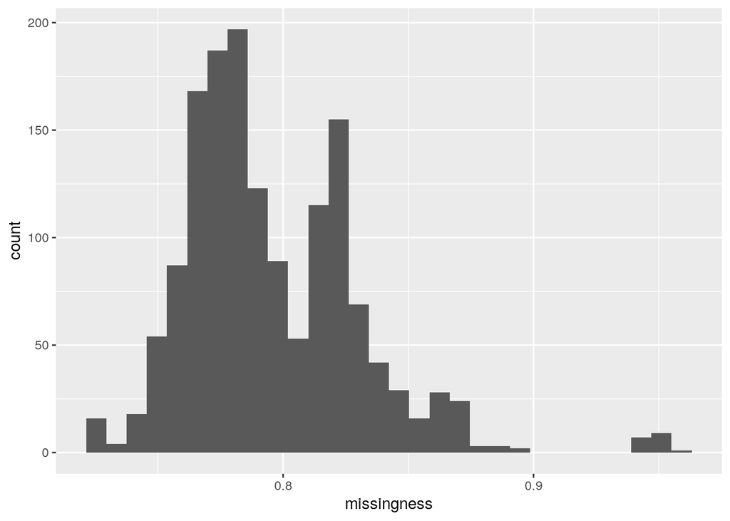

```r
longFormat(scp[, , "proteins_norm2"]) %>%
    data.frame %>%
    group_by(colname) %>%
    summarize(missingness = mean(is.na(value))) %>%
    ggplot(aes(x = missingness)) +
    geom_histogram()
```

The missing data is imputed using K nearest neighbors. The SCoPE2 script runs KNN with k = 3. We made a wrapper around the author’s code to apply imputation to our `QFeatures` object.

```r
scp <- scp_imputeKNN(scp,
                     i = "proteins_norm2",
                     name = "proteins_impd",
                     k = 3)
```

`QFeatures` also provides KNN imputation by calling to the `impute::impute.knn` function. However, the implementation is different in the sense that SCoPE2 performs KNN imputation in the sample space, meaning that data from neighbouring cells are used to impute, whereas `impute::impute.knn` performs KNN imputation in the gene space, meaning that data from neighbouring genes are used to impute the missing values. We provide the code for KNN imputation with `QFeatures` but do not run in order to reproduce the SCoPE2 analysis.

```r
scp <- impute(scp,
              i = "proteins_norm2",
              method = "knn",
              k = 3, rowmax = 1, colmax= 1,
              maxp = Inf, rng.seed = 1234)
```

## 10.3 Batch correction

The final step is to model the remaining batch effects and correct for it. The data were acquired as a series of MS runs. Recall we had 177 assays at the beginning of the workflow. Each MS run can be subjected to small technical perturbations that lead to differences in the data. This can be corrected to avoid attributing biological effects to technical effects. The `ComBat` algorithm (Johnson, Li, and Rabinovic (2007)) is used in the SCoPE2 script to correct for those batch effects. `ComBat` is part of the `sva` package. It requires a batch variable, in this case the LC-MS/MS run, and adjusts for batch effects, while protecting variables of interest, the sample type in this case. All the information is contained in the `colData` of the `QFeatures` object. We first extract the assays with the associate `colData`.

```r
sce <- getWithColData(scp, "proteins_impd")
```

```
## harmonizing input:
##   removing 16489 sampleMap rows not in names(experiments)
```

We next store the batch variable and create the design matrix. We then call the functions and overwrite the data matrix. Recall the data matrix can be accessed using the `assay` function. Note also that we here use `ComBatv3.34` that was loaded at the beginning of the vignette (not shown). This function was taken from an older version of the `sva` package (version `3.34.0`). This is to replicate the SCoPE2 results. More recent versions have implemented a check for within-batch invariant proteins that will ignore batch correction for a protein if at least one of the batch contain constant values.

```r
batch <- colData(sce)$Set
model <- model.matrix(~ SampleType, data = colData(sce))
assay(sce) <- ComBatv3.34(dat = assay(sce),
                          batch = batch,
                          mod = model)
```

Finally, we add the batch corrected assay to the `QFeatures` object and create the feature links.

```r
scp %>%
    addAssay(y = sce,
             name = "proteins_batchC") %>%
    addAssayLinkOneToOne(from = "proteins_impd",
                         to = "proteins_batchC") ->
    scp
```

## 10.4 The SCoPE2 protein data

Before exporting the data as `Proteins-processed.csv`, the authors performed an additional normalization step.

```r
scp %>%
    ## Center columns with median
    sweep(i = "proteins_batchC",
          MARGIN = 2,
          FUN = "-",
          STATS = colMedians(assay(.[["proteins_batchC"]]),
                             na.rm = TRUE),
          name = "proteins_batchC_norm1") %>%
    ## Center rows with mean
    sweep(i = "proteins_batchC_norm1",
          MARGIN = 1,
          FUN = "-",
          STATS = rowMeans(assay(.[["proteins_batchC_norm1"]]),
                           na.rm = TRUE),
          name = "proteins_scp") ->
    scp
```

We named the last assay `proteins_scp`. We will contrast this data matrix to `proteins_SCoPE2` later in the next section to assess the fidelity of the replication.

# 11 Benchmarking the replication

We will now compare the data that were provided by Specht and colleagues with the data generated in this vignette. We compare the peptide and the protein data.

## 11.1 Compare the selected cells

One of the above section filtered the single cells based on the median coefficient of variation per cell. We will check that we could indeed reproduce the SCoPE2 cell filter. Note that the peptide and protein data contain the same set of cells.

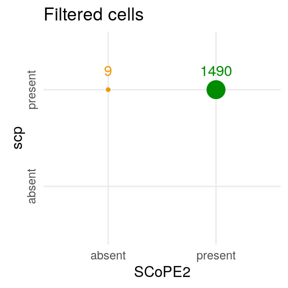

The `scp` filtering step keep 9 additional cells (0.6 % out of all cells) compared to SCoPE2.

## 11.2 Compare peptide data

The SCoPE2 and the `scp` peptide data have comparable dimensions, although they are not exactly the same. Our workflow kept 10 additional peptides out of 9364. Similarly to the filtered cells, this difference is negligible and demonstrate an almost perfect replication of the filtering steps.

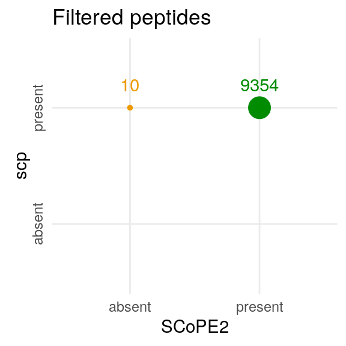

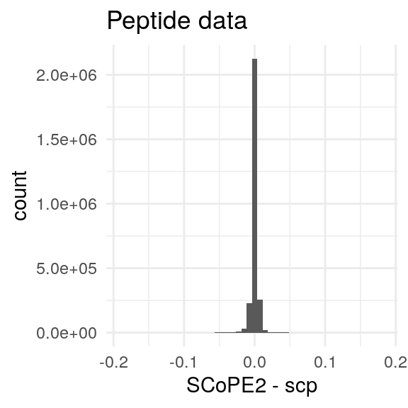

## 11.3 Compare protein data

Similarly to the peptide data, the SCoPE2 and the `scp` protein data contain different but highly overlapping (99.28 %) sets of proteins. It is expected to see more proteins in the `scp` results with respect to `SCoPE2` because this was already seen for the peptide data. However, some proteins are only found in SCoPE2. This is a consequence of the remapping of peptides to proteins that occurred when joining together all the peptides assays in one. This step was required by `scp` to properly aggregate peptides to proteins, but was not considered in the SCoPE2 workflow.

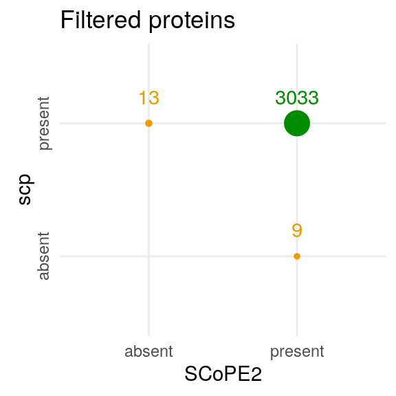

The range of differences between SCoPE2 and `scp` is much wider for the protein data than for the peptide data. The range of the differences between the `scp` and the SCoPE2 data is (-3.06, 2.66) and this comparable to the range of the SCoPE2 protein expression values. However, 99 % of the differences are lying in (-0.45, 0.82) and there is a sharp peak around 0. This indicates that the small differences observed at peptide level have propagated during protein imputation, batch correction and normalization. This is problematic as it indicates that at least one of those steps is unstable. We will the batch correction and the data imputation in a later section.

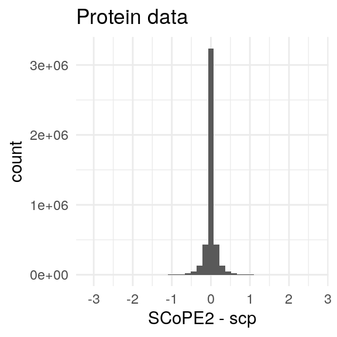

To summarize, here is an overview of the differences between our results using `scp` and the expected results obtained by the `SCoPE2` authors.

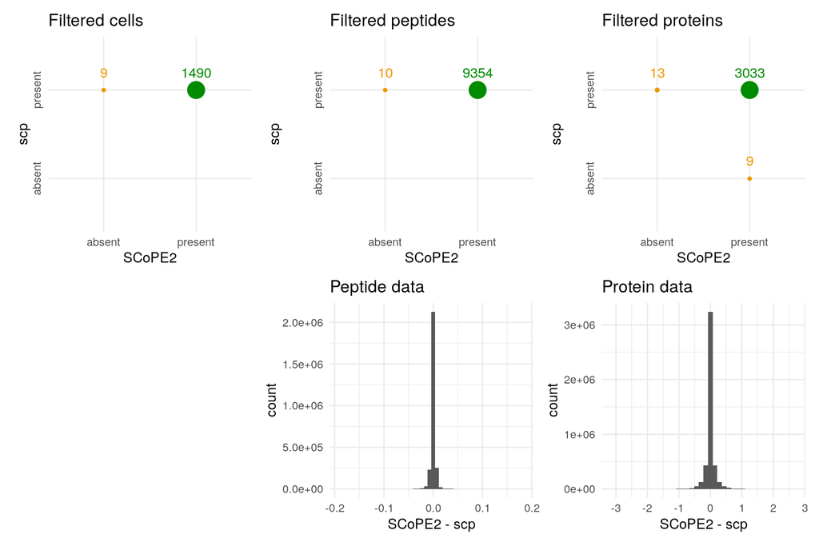

```r
cell_sel +
    peptide_sel +
    protein_sel +
    plot_spacer() +
    peptide_diff +
    protein_diff +
    plot_layout(ncol = 3)
```

## 11.4 PCA

To assess the separability between macrophages and monocytes, Specht and colleagues perform weighted principal component analysis (PCA) on the protein data. The weights are proportional to the amount of correlation between a protein and the other proteins. Computing the weighted PCA requires some manual implementation (taken from the SCoPE2 script). The authors use the expression matrix as input. We can easily get this matrix from the desired assay.

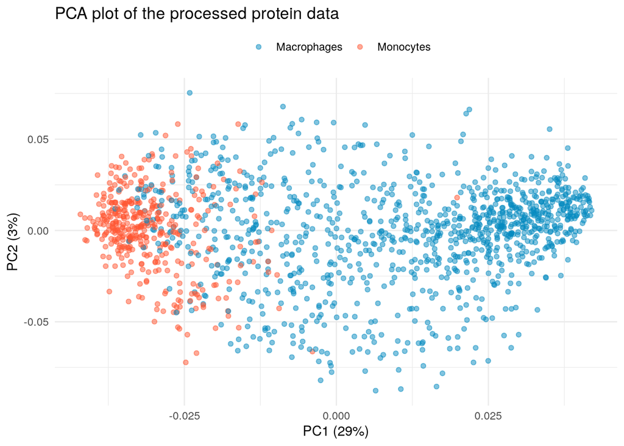

```r
## Extract the protein expression matrix
X <- assay(scp[["proteins_scp"]])
## Compute the weights
w <- rowSums(cor(t(X))^2)
## Compute the PCs (code taken from the SCoPE2 script)
Xw <- diag(w) %*%  X
Xcor <- cor(Xw)
pcaRes <- eigen(Xcor)
pcaPercentVar <- round(pcaRes$values[1:2] / sum(pcaRes$values) * 100)
## Start plotting
data.frame(PC = pcaRes$vectors[, 1:2],
           colData(scp)[colnames(Xcor), ]) %>%
    ggplot(aes(x = PC.1, y = PC.2, col = SampleType)) +
    geom_point(alpha = 0.5) +
    ## Annotate plot
    xlab(paste0("PC1 (", pcaPercentVar[1], "%)")) +
    ylab(paste0("PC2 (", pcaPercentVar[2], "%)")) +
    ggtitle("PCA plot of the processed protein data") +
    ## Adapt the visual style to match the preprint figure
    scale_color_manual(name = "", values = c("#048ABF","#FF5733"),
                       labels = c("Macrophages", "Monocytes")) +
    theme_minimal() +
    theme(legend.position = "top")
```

As a side note, the `scater` packages provides a suite of functions that perform and visualize dimension reduction for `SingleCellExperiment` objects. Since our assays are all `SingleCellExperiment` objects, we can perform regular PCA on the protein data in just a few commands.

```
## harmonizing input:
##   removing 20986 sampleMap rows not in names(experiments)
```

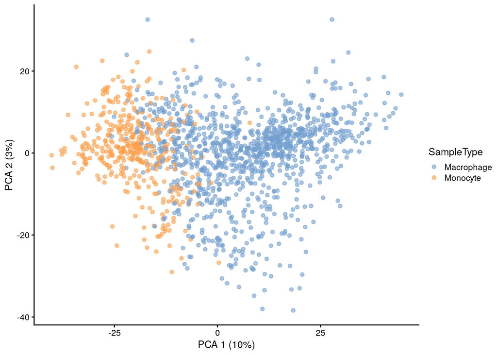

```r
library(scater)
getWithColData(scp, "proteins_scp") %>%
    ## Perform PCA, see ?runPCA for more info about arguments
    runPCA(ncomponents = 50,
           ntop = Inf,
           scale = TRUE,
           exprs_values = 1,
           name = "PCA") %>%
    ## Plotting is performed in a single line of code
    plotPCA(colour_by = "SampleType")
```

This plot is different from the previous plot because no weighting is considered during the second PCA.

```r
## To remove when remainder of vignette is finished
sessionInfo()
```

[output not shown]

[output cut: 79 more lines]

```r
knitr::opts_chunk$set(eval = FALSE)
```